# 运气、能力与零和：温度能分开什么

《公平与效率：同一个温度》的旁支笔记

最后更新：2026-10-29 20:04 EDT

```r
## 与《公平与效率》第 5 章同一套设定：N=2000，能力对数正态 sigma_a=0.8，
## 观测带乘性噪声，产出 sum(a * x^gamma)，gamma=0.5。
set.seed(3)
N <- 2000; R_tot <- N; sig_a <- 0.8; gam <- 0.5
a <- rlnorm(N, 0, sig_a)
sweep_beta <- function(sig_e, betas, nrep = 100){
  t(vapply(betas, function(b){
    o <- g <- numeric(nrep)
    for (k in 1:nrep){
      ah <- a*exp(rnorm(N, 0, sig_e))
      x  <- R_tot * ah^b / sum(ah^b)
      o[k] <- sum(a * x^gam); g[k] <- gini(x)
    }
    c(out = mean(o), gini = mean(g))
  }, numeric(2)))
}
betas <- seq(0, 4, by = 0.2)
sigs  <- c(0, 0.4, 0.8, 1.2)
res   <- lapply(sigs, sweep_beta, betas = betas)
base  <- res[[1]][1, "out"]
bstar <- sapply(res, function(r) betas[which.max(r[, "out"])])
```

这是《公平与效率：同一个温度》的一篇旁支笔记，不并入正文。正文把 $T$ 说成了三样东西：公平与效率的兑换率、对”谁行”的无知程度、以及配置集中度的倒数。**这是旧稿的简化说法**；正文已把 same-T 限定在指数族/特定 logit 信息模型，第三重只在那个模型里对齐，不是恒等；E5 的共担不经过 $T$。这篇笔记要把这个说法往下压一层，回答两个问题：

1. **“正确的温度”能不能把运气带来的财富压下去，同时把非运气的东西挑出来？**
2. **穷人更常是零和思维、富人更常能非零和，这件事要不要进模型？**

两个问题的答案都不是”是”或”否”，而是”要看温度管的是哪一段，以及游戏本身是不是零和”。

> **温度能决定给运气多大的权重，但决定不了运气在配置里占多大份额。** 份额由信噪比决定；把噪声压下去的是重复观测或工具，不是温度。 **零和还是非零和，决定的也不是温度高低，而是公平与效率是否对立。**

这篇笔记先把这两件事推出来，再把它们接回《再论不平等的起源》的机制分类。

# 1 温度是一个标量，不是过滤器

回到《公平与效率》第 5 章那台机器：真实能力 $a_i$，观测 $\hat a_i=a_i e^{\varepsilon_i}$，配置 $x_i\propto \hat a_i^{\beta}$。取对数：

$$\log x_i=\text{常数}+\beta\log
a_i+\beta\varepsilon_i.$$

**温度（$\beta$ 的倒数）同时乘在两项上。** 它可以把整个配置拉平或推陡，但拉不开”能力”和”运气”这两项之间的比例。对数配置方差里来自运气的那一份是

$$\ell=\frac{\operatorname{Var}(\beta\varepsilon)}{\operatorname{Var}(\beta\log
a+\beta\varepsilon)}=\frac{\sigma_\varepsilon^2}{\sigma_a^2+\sigma_\varepsilon^2},$$

**与 $\beta$ 无关。** 这是这篇笔记要说的第一件事，也是对上文那句直觉的第一个修正：温度能压低运气带来的财富的**绝对量**，压不掉它在配置里的**份额**。

用《公平与效率》第 5 章同一组参数（$\sigma_a=0.8$、$\sigma_\varepsilon=0.8$），从那张扫描里取四个点，$\beta$ 从 0.2 到 3.0：

温度改变集中度，不改变运气份额

| 配置集中度 β | 产出（等分=1） | 配置的基尼 | 运气占对数配置方差的份额 |
| --- | --- | --- | --- |
| 0.2 | 1.058 | 0.127 | 0.50 |
| 1.0 | 1.169 | 0.574 | 0.50 |
| 2.0 | 1.003 | 0.882 | 0.50 |
| 3.0 | 0.707 | 0.974 | 0.50 |

表里三列结果要一起读：$\beta$ 从 0.2 到 3.0，基尼从 0.127 到 0.974，产出先升后降；**运气份额一列一动不动，全是 0.50**。《公平与效率》第 5 章说”噪声把最优集中度往下推”，那是说**峰的位置**在动；这张表说的是**峰的成分**没动。最优点 $\beta^\ast=$ 1.0 处，产出比等分高 17%，而对数配置方差里仍有 50% 来自运气。**“正确的温度”没有把运气挑掉，它只是给运气定了价。**

这不是说温度没用。它说的是：**温度是一个标量，不是一个筛子。** 要改变份额，得改变 $\sigma_\varepsilon$ 和 $\sigma_a$ 的比——也就是改变你手里的证据，而不是改变你给证据的权重。

# 2 真正压掉运气份额的是重复观测

现实里同一个人不会只被观测一次。把 $t$ 次观测的平均写成 $\bar\varepsilon_{it}$，它服从 $N(0,\sigma_\varepsilon^2/t)$。于是第 $t$ 期的有效噪声是

$$\sigma_t=\frac{\sigma_\varepsilon}{\sqrt
t},$$

《公平与效率》第 5 章的静态实验可以原样重跑，只要把 $\sigma_\varepsilon$ 换成 $\sigma_t$。**这是一条精确的等价，不是近似**：$t$ 次独立观测的均值，和一次噪声缩小 $\sqrt t$ 倍的观测，分布完全相同。

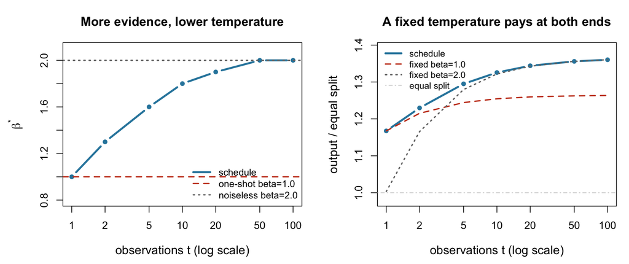

证据越多，最优温度越低；固定温度在两端付代价

| 观测次数 t | 有效噪声 σ | 最优集中度 β* | 运气份额 | 产出（等分=1） | 固定 β=1 的产出 | 固定 β=2 的产出 | 最优点基尼 |
| --- | --- | --- | --- | --- | --- | --- | --- |
| 1 | 0.800 | 1.0 | 0.500 | 1.167 | 1.167 | 1.003 | 0.575 |
| 2 | 0.566 | 1.3 | 0.333 | 1.230 | 1.215 | 1.166 | 0.628 |
| 5 | 0.358 | 1.6 | 0.167 | 1.295 | 1.244 | 1.280 | 0.674 |
| 10 | 0.253 | 1.8 | 0.091 | 1.326 | 1.255 | 1.322 | 0.709 |
| 20 | 0.179 | 1.9 | 0.048 | 1.344 | 1.260 | 1.343 | 0.723 |
| 50 | 0.113 | 2.0 | 0.020 | 1.356 | 1.262 | 1.356 | 0.740 |
| 100 | 0.080 | 2.0 | 0.010 | 1.360 | 1.263 | 1.360 | 0.738 |

```r
TT <- c(1, 2, 5, 10, 20, 50, 100)
SIG_E0 <- sigs[3]
betas_fine <- seq(0, 4, by = 0.1)
set.seed(166)
DYN <- lapply(TT, function(tt) sweep_beta(SIG_E0/sqrt(tt), betas = betas_fine, nrep = 300))
B1 <- bstar[3]; B2 <- 1/(1 - gam)
dyn <- do.call(rbind, lapply(seq_along(TT), function(i){
  r <- DYN[[i]]; k <- which.max(r[, "out"])
  data.frame(t = TT[i], sig_t = SIG_E0/sqrt(TT[i]), bstar = betas_fine[k],
             luck = SIG_E0^2/(TT[i]*sig_a^2 + SIG_E0^2),
             out = r[k, "out"]/base,
             out_b1 = r[which.min(abs(betas_fine - B1)), "out"]/base,
             out_b2 = r[which.min(abs(betas_fine - B2)), "out"]/base,
             gini = r[k, "gini"])
}))
loss_b1 <- 1 - dyn$out_b1[nrow(dyn)]/dyn$out[nrow(dyn)]
loss_b2 <- 1 - dyn$out_b2[1]/dyn$out[1]
stopifnot(abs(B1 - 1) < 1e-9, abs(B2 - 2) < 1e-9)

par(mfrow = c(1, 2), mar = c(4.6, 5.0, 3.4, 1.0))
plot(TT, dyn$bstar, log = "x", type = "b", pch = 16, lwd = 3, col = "#2E86AB",
     ylim = c(0.8, 2.1), xlab = "observations t (log scale)",
     ylab = expression(beta^"*"), main = "More evidence, lower temperature", cex.lab = 1.15)
abline(h = B1, lty = 2, col = "#C73E1D", lwd = 2)
abline(h = B2, lty = 3, col = "gray45", lwd = 2)
legend("bottomright", c("schedule", sprintf("one-shot beta=%.1f", B1), sprintf("noiseless beta=%.1f", B2)),
       col = c("#2E86AB", "#C73E1D", "gray45"), lwd = c(3, 2, 2), lty = c(1, 2, 3), bty = "n", cex = 0.9)

plot(TT, dyn$out, log = "x", type = "b", pch = 16, lwd = 3, col = "#2E86AB",
     ylim = range(c(dyn$out, dyn$out_b1, dyn$out_b2, 1)) + c(-0.02, 0.03),
     xlab = "observations t (log scale)", ylab = "output / equal split",
     main = "A fixed temperature pays at both ends", cex.lab = 1.15)
lines(TT, dyn$out_b1, col = "#C73E1D", lwd = 2, lty = 2)
lines(TT, dyn$out_b2, col = "gray45", lwd = 2, lty = 3)
abline(h = 1, col = "gray80", lty = 4)
legend("topleft", c("schedule", sprintf("fixed beta=%.1f", B1), sprintf("fixed beta=%.1f", B2), "equal split"),
       col = c("#2E86AB", "#C73E1D", "gray45", "gray80"), lwd = c(3, 2, 2, 1), lty = c(1, 2, 3, 4), bty = "n", cex = 0.85)
```

表里最后两行的基尼差（0.740 对 0.738）是 300 次重复的 Monte Carlo 噪声——两行的 $\beta^\ast$ 都已到无噪声上限 2.0，不应读成趋势。

表和图要读三件事：

- **最优集中度随 $t$ 上升**：$\beta^\ast_t$ 从 1.0 走到 2.0。观测越多，越敢把资源压到被反复确认的人身上。
- **运气份额随 $t$ 下降**：从 0.500 降到 0.0099。降它的不是 $\beta_t$，是 $\sqrt t$——在每一个 $t$ 上，改 $\beta$ 仍然不改变份额（上一节）。
- **固定温度在两端都要付代价**：把第 1 期的 $\beta^\ast$ 一直用下去，到第 100 期产出比日程低 7.1%；把无噪声的 $\beta=2$ 从第 1 期就用上，第 1 期就损失 14.1%。日程不是”更激进”或”更保守”，它是**在正确的时间做正确的事**。

所以”正确的温度”不是一个数，是一条日程：

$$T_t=\frac{1}{\beta_t^\ast},\qquad T_t\
\text{随}\ t\ \text{下降}.$$

这句话有一个容易滑过去的点：**日程之所以对，是因为 $\sigma_t$ 在降，不是因为 $T_t$ 在降。** 如果观测没有变多，把温度调来调去只是在同一个信噪比上换一个点；如果观测变多，温度不调，配置也会自己变得更贴近能力（因为 $\hat a_t$ 更准），只是没有把这份信息用足。**温度是剩余不确定性的影子价格；降低不确定性的是证据，不是价格。**

# 3 永久运气：温度碰不到的那一半

上面的”运气”是**暂时的**：它会平均掉。还有另一种运气，是**一次性的**：出生在谁家、赶上哪一波、抽到哪一块地。这种运气和能力在观测上完全同形——如果

$$\log a_i=\alpha_i+\eta_i,\qquad \eta_i\
\text{永久},$$

那么每一期的信号都是 $\alpha_i+\eta_i+\bar\varepsilon_{it}$，$\alpha$ 和 $\eta$ 的系数永远都是 1。**再多的 $t$ 也分不开它们**；能分的只有外生的随机分配、自然实验、或者一个把 $\eta$ 和 $\alpha$ 分开的结构假设。

这就是这篇笔记的硬边界，也是”正确的温度”最容易被打折的地方：

> **温度只能给残余不确定性定价；它不能告诉你残余不确定性里哪一部分是运气。** 永久运气与能力不可分时，$T$ 是一个**规范选择**，不是一个**估计量**。

这句话和《公平与效率》第 8 章末尾那个”还差一个量”是同一件事。那里说，永久／暂时分解 (Gottschalk and Moffitt 2009) 需要面板数据和一个时间尺度确定的收入；这里说，那个分解同时还是**温度的输入**。没有它，你可以算”给定信噪比的最优温度”，但算不出”这个社会的信噪比是多少”。

# 4 零和与非零和：公平何时免费

第二个问题看起来是心理学的，其实先是一个**可行集**的问题。

**定义。** 一个互动是**零和**的，如果参与者的总支付固定，一个人多拿一块，另一个人就少一块；是**非零和**的，如果总支付可以随配置和行动变大。

这个定义直接决定公平-效率前沿的形状：

|  | 总支付 | 前沿 | 温度的作用 | 例子 |
| --- | --- | --- | --- | --- |
| **零和** | 固定 | 固定总支付的那条线；纯分配里整条单纯形都是帕累托最优 | 只能在前沿上换一个点；不改变总产出 | 纯交换、定额争夺、固定的奖池 |
| **非零和** | 可变 | 可以弯；存在”更平等且总产出更高”的区段 | 可以选到更有产出的均衡；可能双赢 | 生产、互补性、公共品、合作 |

《公平与效率》第 4 章那句”任何把资源分完的方案都是帕累托最优的”就是零和那一行。《公平与效率》第 5 章那个”越过 $\beta^\ast$ 之后产出和公平同时下降”的区段，只可能在非零和那一行出现——**如果总支付固定，“同时下降”根本没有空间。** 所以《公平与效率》开头那个乐观命题，有一个从未写出来的前提：

> **“公平不是效率的对立面”只在非零和的生产结构里成立。** 在零和里，它确实是对立面；温度只是决定你站在对立面的哪一端。

这就把”穷人零和、富人非零和”接进来了，但接法不是人格，是约束：

- **穷人更常面对零和可行集**：没有余粮投资、没有抵押品、没有保险、当期消费不能等。在这些约束下，抢一块固定的饼是理性的，不是认知缺陷。
- **富人更常能进入非零和**：可以投资、可以分散、可以等、可以签合同、可以合作生产。非零和不要求他们更善良，只要求他们付得起固定成本。
- **箭头可以反过来**：零和信念可能压低合作与投资，从而让零和约束继续绑着——如果这条反馈成立，就是一个信念陷阱，不是一次性的人格差异。

**但不要把这句话读成”穷人都是零和思维”。** 那是把约束读成了人格。可检验的版本是：**在同一套偏好下，把可行集从零和换成非零和，零和行为应当下降。** 这条预测可以用转移、信贷、保险或公共品的外生变化去检验；人格版本在这里没有独立推论。

一个最小的门槛例子能把”公平何时免费”写成条件。设一项生产需要固定成本 $c$，参与后产出增加 $A$；某人的财富是 $w<c$，他拿不出这笔钱。一笔 $c-w$ 的转移把他推过门槛，总产出增加 $A$。只要

$$A>c-w,$$

产出增加 $A$ 大于转移额 $c-w$：拿到转移的人变好，捐出转移的人也能从多出来的产出里得到补偿——这是一次帕累托改进，平等和效率同向。反过来，如果 $w\ge c$，同样的转移只是把钱从一个人挪到另一个人，总产出不变——那是零和。**同一条再分配规则，在门槛两边是两个完全不同的游戏。**

所以”要不要考虑零和/非零和”的答案是：**要，而且它比温度更靠前。** 温度决定你在前沿上选哪一点；零和/非零和决定这条前沿是不是一条纯粹的权衡。**先看游戏，再看温度。**

# 5 三层分开，分工才清楚

把这篇笔记压成三句话：

1. **温度层**：$T$ 是剩余不确定性的影子价格。它决定配置的集中度，不决定运气在配置里的份额。
2. **证据层**：重复观测、面板、随机分配——这些才改变信噪比，才把暂时运气平均掉。永久运气在这一层也分不掉，需要工具或结构假设。
3. **生产层**：零和还是非零和，决定公平与效率是否对立。穷人更常被零和约束挡住，富人更常能进入非零和；这是可行集差异，不是人格差异。

三个层次混在一起，会得到三个常见的错：

- 把 $T$ 当过滤器 → 以为调温度就能”挑出能力”；
- 把一个固定的 $T$ 当正确答案 → 在证据变多时继续用旧温度；
- 把”公平免费”当普适定理 → 在零和世界里硬套非零和的结论。

反过来，三层分开，《再论不平等的起源》和《公平与效率》就有了一个清楚的分工：

- **《再论不平等的起源》**回答”不平等从哪来”：它给出零和基线、乘性增长，以及第 6 章那三族机制。
- **《公平与效率》**回答”给定这些机制，该给不确定性定什么价”：它给出 $T$ 的框架；这篇笔记把 $T$ 拆成一条随证据变化的日程。
- **接点**是永久／暂时分解：《再论不平等的起源》的机制决定哪些差异是持久的，这篇笔记的 $T$ 日程给这些差异定价。**没有分解，$T$ 只是一个漂亮的参数；有了分解，$T$ 才是一个可以报出来的数。**

这也正好接上《公平与效率》第 8 章。那一章要说”一个数不够”：基尼分不出运气和能力的份额，位置粘性分不出位置牢在什么上，互信息分不出”追踪”与”制造”。这篇笔记补的是它们背后那一层——**同样是基尼 0.5，一个高运气的社会和一个高能力的社会，正确的温度不一样，政策的工具也不一样。**

# 参考文献

Gottschalk, Peter, and Robert Moffitt. 2009. “The Rising Instability of u.s. Earnings.” *Journal of Economic Perspectives* 23 (4): 3–24. https://doi.org/10.1257/jep.23.4.3.